# DSO 522: In-Class Workbook 11

Matteo Sesia

November 5, 2024

# Instructions

Your task is to edit this R Markdown notebook to include your solutions, ensuring that it is well-organized and professional in appearance. Answers must be clear and concise. Start by downloading the Rmd file.

**Collaboration Policy.** You are allowed to discuss this workbook with your classmates and work in groups. Despite group discussions, each student must write and submit their own solutions.

**Assistance Policy.** You may ask for clarifications from the instructor and teaching assistant in class. Do not seek help on these workbooks outside of class, as they are intended to be completed during class time.

**Submission Requirements.** Solutions must be submitted on Brightspace as a PDF writeup. Use the ‘Knit to PDF’ feature in RStudio to prepare your PDF document. Ensure that your PDF document looks like the provided PDF version of the workbook, including all code used to obtain the results in proper code blocks. Make sure your PDF writeup includes *your name* in the title (replace my name with yours).

**Grading Criteria.** This workbook is worth 10 points. To achieve a grade of 10, your writeup must correctly answer all questions, be easy to understand, and be formatted correctly.

**Work Timeline.** You are expected to work on this assignment in class, but you may complete it at home within 24 hours. It is due on November 6, 2024, at 9:30 pm. Late submissions will incur a 50% deduction for any initial delay below 24 hours, and an additional 10% deduction for each additional day.

Remember, you will need to use the `fpp3` package to complete this assignment, as shown in the lecture.

```r
suppressMessages(library(fpp3))
```

# Problem 1

This exercise uses data set `LakeHuron` giving the level of Lake Huron from 1875–1972.

1. Convert the data to a tsibble object using the `as_tsibble()` function.
2. Fit a piecewise linear trend model to the Lake Huron data with a knot at 1920 and an ARMA error structure.
3. Forecast the level for the next 30 years. Do you think the extrapolated linear trend is realistic?

# Problem 1 Solutions

1. Convert the data to a tsibble object using the `as_tsibble()` function.

```r
huron <- as_tsibble(LakeHuron)
```

2. Fit a piecewise linear trend model to the Lake Huron data with a knot at 1920 and an ARMA error structure.

```r
fit <- huron |>
  model(ARIMA(value ~ trend(knot = 1920)))
report(fit)
```

```
Series: value
Model: LM w/ ARIMA(2,0,0) errors

Coefficients:
         ar1      ar2  trend(knot = 1920)trend  trend(knot = 1920)trend_46
      0.9628  -0.3107                  -0.0572                      0.0633
s.e.  0.0973   0.0983                   0.0161                      0.0265
      intercept
       580.9391
s.e.     0.5124

sigma^2 estimated as 0.4594:  log likelihood=-98.86
AIC=209.73   AICc=210.65   BIC=225.24
```

3. Forecast the level for the next 30 years. Do you think the extrapolated linear trend is realistic?

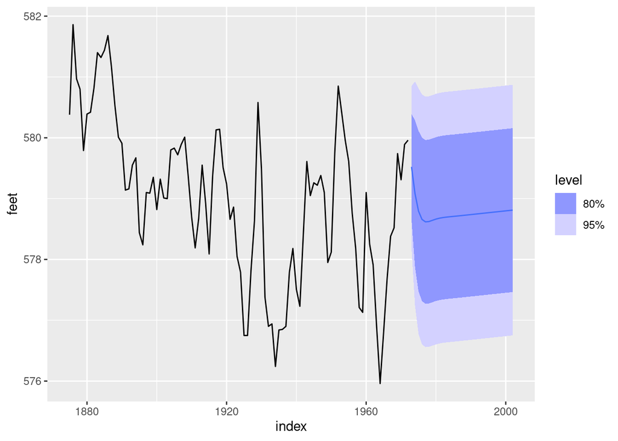

```r
fit |>
  forecast(h = 30) |>
  autoplot(huron) + labs(y = "feet")
```

It seems unlikely that there was an increasing trend from 1973 to 2002, but the prediction intervals are very wide so they probably capture the actual values. Historical data on the level of Lake Huron can be obtained from the [NOAA](https://tidesandcurrents.noaa.gov/waterlevels.html?id=9075014&bdate=19730101&edate=20020101&datum=IGLD&interval=m&action=data).

# Problem 2

This exercise concerns `aus_accommodation`: the total quarterly takings from accommodation and the room occupancy level for hotels, motels, and guest houses in Australia, between January 1998 and June 2016. Total quarterly takings are in millions of Australian dollars.

1. Compute the CPI-adjusted takings and plot the result for each state
2. For each state, fit a dynamic regression model of CPI-adjusted takings with seasonal dummy variables, a piecewise linear time trend with one knot at 2008 Q1, and ARIMA errors.
3. Check that the residuals of the model look like white noise.
4. Forecast the takings for each state to the end of 2017. (Hint: You will need to produce forecasts of the CPI first.)
5. What sources of uncertainty have not been taken into account in the prediction intervals?

# Problem 2 Solutions

1. Compute the CPI-adjusted takings and plot the result for each state

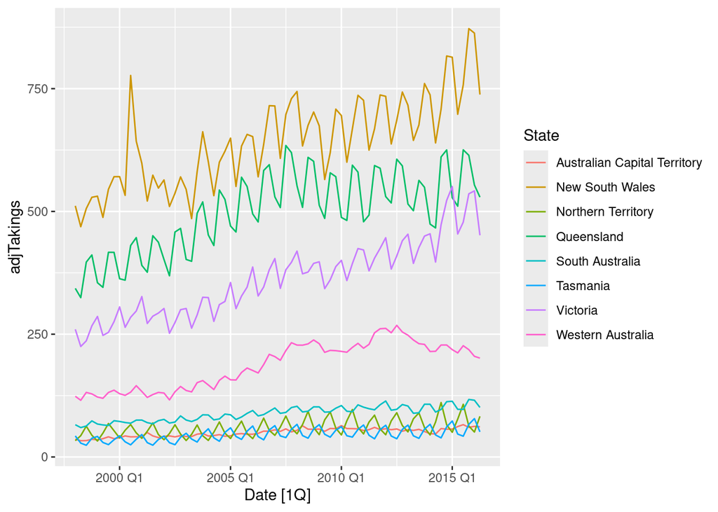

```r
aus_accommodation <- aus_accommodation |>
  mutate(
    adjTakings = Takings / CPI * 100
  )
aus_accommodation |>
  autoplot(adjTakings)
```

2. For each state, fit a dynamic regression model of CPI-adjusted takings with seasonal dummy variables, a piecewise linear time trend with one knot at 2008 Q1, and ARIMA errors.

```r
fit <- aus_accommodation |>
  model(
    ARIMA(adjTakings ~ season() + trend(knot = yearquarter("2008 Q1")))
  )
fit
```

[output not shown]

The seasonal dummy variable has not adequately handled the seasonality, so there are seasonal ARIMA components.

3. Check that the residuals of the model look like white noise.

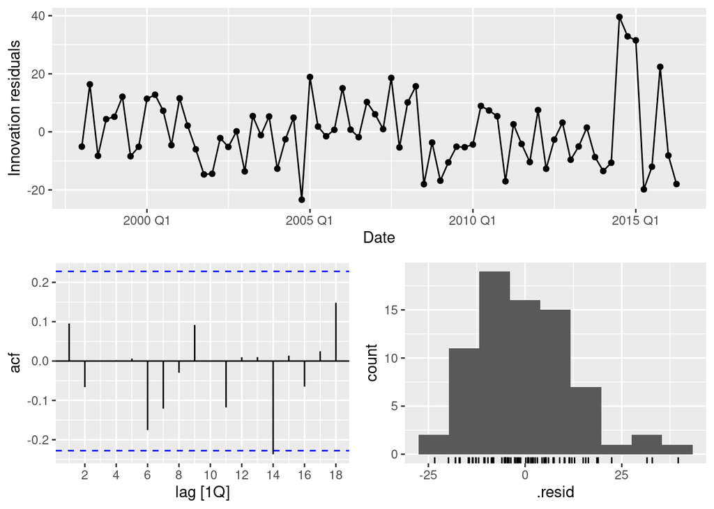

```r
fit |>
  filter(State == "Victoria") |>
  gg_tsresiduals()
```

No apparent problems. Similar plots needed for the other states.

4. Forecast the takings for each state to the end of 2017. (Hint: You will need to produce forecasts of the CPI first.)

```r
# CPI forecasts
cpif <- aus_accommodation |>
  model(ARIMA(CPI)) |>
  forecast(h = 6) |>
  as_tsibble() |>
  select(Date, State, CPI = .mean)
fit |>
  forecast(new_data = cpif) |>
  mutate(Takings = adjTakings * CPI / 100)
```

| State | .model | Date | adjTakings | .mean | CPI | Takings |
| --- | --- | --- | --- | --- | --- | --- |
| Australian Capital Territory | ARIMA(adjTakings ~ season() + trend(knot = yearquarter("2008 Q1"))) | 2016 Q3 |  | 61.62067 | 109.1699 |  |
| Australian Capital Territory | ARIMA(adjTakings ~ season() + trend(knot = yearquarter("2008 Q1"))) | 2016 Q4 |  | 58.91323 | 109.7397 |  |
| Australian Capital Territory | ARIMA(adjTakings ~ season() + trend(knot = yearquarter("2008 Q1"))) | 2017 Q1 |  | 58.96583 | 110.3096 |  |
| Australian Capital Territory | ARIMA(adjTakings ~ season() + trend(knot = yearquarter("2008 Q1"))) | 2017 Q2 |  | 59.43673 | 110.8795 |  |
| Australian Capital Territory | ARIMA(adjTakings ~ season() + trend(knot = yearquarter("2008 Q1"))) | 2017 Q3 |  | 60.88992 | 111.4493 |  |
| Australian Capital Territory | ARIMA(adjTakings ~ season() + trend(knot = yearquarter("2008 Q1"))) | 2017 Q4 |  | 58.83106 | 112.0192 |  |
| New South Wales | ARIMA(adjTakings ~ season() + trend(knot = yearquarter("2008 Q1"))) | 2016 Q3 |  | 790.62110 | 109.1699 |  |
| New South Wales | ARIMA(adjTakings ~ season() + trend(knot = yearquarter("2008 Q1"))) | 2016 Q4 |  | 843.98348 | 109.7397 |  |
| New South Wales | ARIMA(adjTakings ~ season() + trend(knot = yearquarter("2008 Q1"))) | 2017 Q1 |  | 829.15011 | 110.3096 |  |
| New South Wales | ARIMA(adjTakings ~ season() + trend(knot = yearquarter("2008 Q1"))) | 2017 Q2 |  | 733.75935 | 110.8795 |  |

[output cut: 38 more lines]

5. What sources of uncertainty have not been taken into account in the prediction intervals?
- The uncertainty in the CPI forecasts has been ignored.
- As usual, the estimation of the parameters and the choice of models have also not been accounted for.